# Expedia點擊率預測(期中進度)

蔡漢龍 沈柏宇 梁家安

19th April 2017

# 1 簡介

這是[kaggle](https://www.kaggle.com/c/expedia-personalized-sort)有關Expedia網站的資料，我們要預測使用者在網站搜尋後，在推薦清單上的點擊率(click_bool)。目前是用R運行，但在Spark上遇到些問題仍未解決，期末會轉至Python，配搭Spark及Google Cloud Platform執行。期中報告使用train.csv前三十五萬筆資料(100MB)，選取的方法為分類樹(Decision Tree)，考慮到個人電腦運算速度及負荷，分類樹執行速度較快，至於較複雜或運算時間較長的方法如隨機森林(Random Forest)則後續至Google Cloud Platform上執行。

目前遇到的難題，是資料不平均，只有少數資料顯示點擊，如果全部預測不會點擊，準確率高達95%，但無法判斷會點擊的人次。針對上述問題，本次採用方法為使點擊及不點擊資料比例接近1:1，使用Under-Sampling及Over-Sampling的方法，但效果未如理想，之後會嘗試加權或其他演算法。

# 2 讀檔

```r
library(rpart)
library(rpart.plot)
library(dplyr)
library(ggplot2)
library(corrplot)
library(RColorBrewer)
library(readr)
dat = read_csv('train.csv', n_max = 350000, na = 'NULL',
               col_types = cols(booking_bool = col_logical(),
                                click_bool = col_logical(),
                                position = col_number(),
                                prop_id = col_character(),
                                random_bool = col_logical(),
                                site_id = col_character(),
                                srch_id = col_character(),
                                visitor_location_country_id = col_character(),
                                visitor_hist_adr_usd = col_number(),
                                srch_destination_id = col_character(),
                                prop_country_id = col_character(),
                                srch_saturday_night_bool = col_logical(),
                                prop_brand_bool = col_logical(),
                                promotion_flag = col_logical()
               )
)
```

## 2.1 資料大小

```r
format(object.size(dat), units = "Mb")
```

```
## [1] "104.4 Mb"
```

# 3 資料描述

## 3.1 以人次計算

點擊次數 ÷ 曝光次數

```r
sum(dat$click_bool>0) / dim(dat)[1]
```

```
## [1] 0.04487143
```

訂房次數 ÷ 曝光次數

```r
sum(dat$booking_bool>0) / dim(dat)[1]
```

```
## [1] 0.02791429
```

訂房次數 ÷ 點擊次數

```r
sum(dat$booking_bool>0) / sum(dat$click_bool>0)
```

```
## [1] 0.6220949
```

# 4 篩選欄位

## 4.1 篩選條件

NA太多及種類太多的刪除。建模時出現NA的該筆資料會被刪去，使樣本數減少；一些欄NA太多的欄位亦不適宜填補，因無法反映資料真實狀況；種類太多在訓練資料時可以使用，但在實驗資料若出現新的種類，則會無法辨識；hist欄位的資料，之後可新增一欄判斷使用者有沒有登入帳號；至於與其他競爭對手對比，即comp欄位，之後會以相加或取平均方式處理；date_time之後可考慮截取年月日星期為欄位；position在test.csv中沒有，詢問助教後說這次只用train.csv,可以選用；book_bool則不能放，因為預測為click_bool，會有邏輯矛盾。這次以最簡單的原則選取欄位。

## 4.2 格式判斷

欄位格式方面，假設prop_review_score及position為數字，即’5’>‘4’>‘3’以及’5’-‘4’=‘4’-‘3’；site_id則改為字串。

```r
t1 = vector()
for (i in 1:dim(dat)[2]){
        t1[i] = sum(is.na(dat[,i]))
}

naPercent = data.frame(colname = colnames(dat),
                na = t1, percent = round(t1/dim(dat)[1]*100,2),
                class = as.vector(unlist(sapply(dat,class)))[-3]
           ) %>%
        arrange(-percent, class)
naPercent$keep = c(rep('X',30),'O','X','O',rep('X',4),rep('O',11), 'X', rep('O',4), 'X')

naPercent = naPercent %>%
        arrange(keep, -percent, class)
knitr::kable(naPercent)
```

| colname | na | percent | class | keep |
| --- | --- | --- | --- | --- |
| prop_review_score | 498 | 0.14 | numeric | O |
| site_id | 0 | 0.00 | character | O |
| prop_starrating | 0 | 0.00 | integer | O |
| srch_length_of_stay | 0 | 0.00 | integer | O |
| srch_booking_window | 0 | 0.00 | integer | O |
| srch_adults_count | 0 | 0.00 | integer | O |
| srch_children_count | 0 | 0.00 | integer | O |
| srch_room_count | 0 | 0.00 | integer | O |
| prop_brand_bool | 0 | 0.00 | logical | O |
| promotion_flag | 0 | 0.00 | logical | O |
| srch_saturday_night_bool | 0 | 0.00 | logical | O |
| random_bool | 0 | 0.00 | logical | O |
| click_bool | 0 | 0.00 | logical | O |
| prop_location_score1 | 0 | 0.00 | numeric | O |
| prop_log_historical_price | 0 | 0.00 | numeric | O |
| position | 0 | 0.00 | numeric | O |
| price_usd | 0 | 0.00 | numeric | O |
| comp1_rate_percent_diff | 343129 | 98.04 | character | X |
| comp6_rate_percent_diff | 343015 | 98.00 | integer | X |
| comp1_rate | 341385 | 97.54 | character | X |
| comp1_inv | 340716 | 97.35 | character | X |
| comp4_rate_percent_diff | 340532 | 97.29 | integer | X |
| gross_bookings_usd | 340230 | 97.21 | numeric | X |
| comp7_rate_percent_diff | 339951 | 97.13 | integer | X |
| comp6_rate | 332553 | 95.02 | integer | X |
| visitor_hist_starrating | 331863 | 94.82 | numeric | X |
| visitor_hist_adr_usd | 331802 | 94.80 | numeric | X |
| comp6_inv | 330989 | 94.57 | integer | X |
| comp4_rate | 327778 | 93.65 | integer | X |
| srch_query_affinity_score | 327616 | 93.60 | numeric | X |
| comp7_rate | 327530 | 93.58 | integer | X |
| comp4_inv | 325310 | 92.95 | integer | X |
| comp7_inv | 324575 | 92.74 | integer | X |
| comp3_rate_percent_diff | 316400 | 90.40 | integer | X |
| comp2_rate_percent_diff | 310896 | 88.83 | integer | X |
| comp8_rate_percent_diff | 307213 | 87.78 | integer | X |
| comp5_rate_percent_diff | 291190 | 83.20 | integer | X |
| comp3_rate | 240760 | 68.79 | integer | X |
| comp3_inv | 232530 | 66.44 | integer | X |
| comp8_rate | 215659 | 61.62 | integer | X |
| comp8_inv | 210594 | 60.17 | integer | X |
| comp2_rate | 206959 | 59.13 | integer | X |
| comp2_inv | 199590 | 57.03 | integer | X |
| comp5_rate | 192996 | 55.14 | integer | X |
| comp5_inv | 183203 | 52.34 | integer | X |
| orig_destination_distance | 112978 | 32.28 | numeric | X |
| prop_location_score2 | 76181 | 21.77 | numeric | X |
| srch_id | 0 | 0.00 | character | X |
| visitor_location_country_id | 0 | 0.00 | character | X |
| prop_country_id | 0 | 0.00 | character | X |
| prop_id | 0 | 0.00 | character | X |
| srch_destination_id | 0 | 0.00 | character | X |
| booking_bool | 0 | 0.00 | logical | X |
| date_time | 0 | 0.00 | POSIXct | X |

```r
# select some columns
dataSelect = dat %>% select(
        # srch_id,
        # date_time,
        site_id,                                  # 29可以等樣本數大d先放
        # visitor_location_country_id,            # 56
        # visitor_hist_starrating,
        # visitor_hist_adr_usd,
        # prop_country_id,                        # 62
        # prop_id,                                # 14568
        prop_starrating,
        prop_review_score,
        prop_brand_bool,
        prop_location_score1,
        # prop_location_score2,                     # 2187 NAs
        prop_log_historical_price,
        position,                                # 很重要，但真testing data沒有
        price_usd,
        promotion_flag,
        # srch_destination_id,
        srch_length_of_stay,
        srch_booking_window,                       #(可考慮整合0-5,6-10)
        srch_adults_count,
        srch_children_count,
        srch_room_count,
        srch_saturday_night_bool,
        # srch_query_affinity_score,               # 3137 NAs
        # orig_destination_distance,               # NAs
        random_bool,
        # comp1_rate,                              # 可相加或取平均處理, 可能大量雜訊，例如忽視自己分數較低填NA. bool相加，diff取平均, NA<-0
        # comp1_inv,
        # comp1_rate_percent_diff,
        # comp2_rate,
        # comp2_inv,
        # comp2_rate_percent_diff,
        # comp3_rate,
        # comp3_inv,
        # comp3_rate_percent_diff,
        # comp4_rate,
        # comp4_inv,
        # comp4_rate_percent_diff,
        # comp5_rate,
        # comp5_inv,
        # comp5_rate_percent_diff,
        # comp6_rate,
        # comp6_inv,
        # comp6_rate_percent_diff,
        # comp7_rate,
        # comp7_inv,
        # comp7_rate_percent_diff,
        # comp8_rate,
        # comp8_inv,
        # comp8_rate_percent_diff,
        click_bool                                      # 很重要，本次預測目標
        # gross_bookings_usd,                           # 很重要，但真testing data沒有
        # booking_bool                                  # 很重要，但真testing data沒有
        ) %>%
        na.omit() %>%
        as.data.frame()
```

## 4.3 相關係數

欄位之間的相關性較低,無共線性問題。但click_bool與其他欄位相關係數接近零，似乎不是好事。

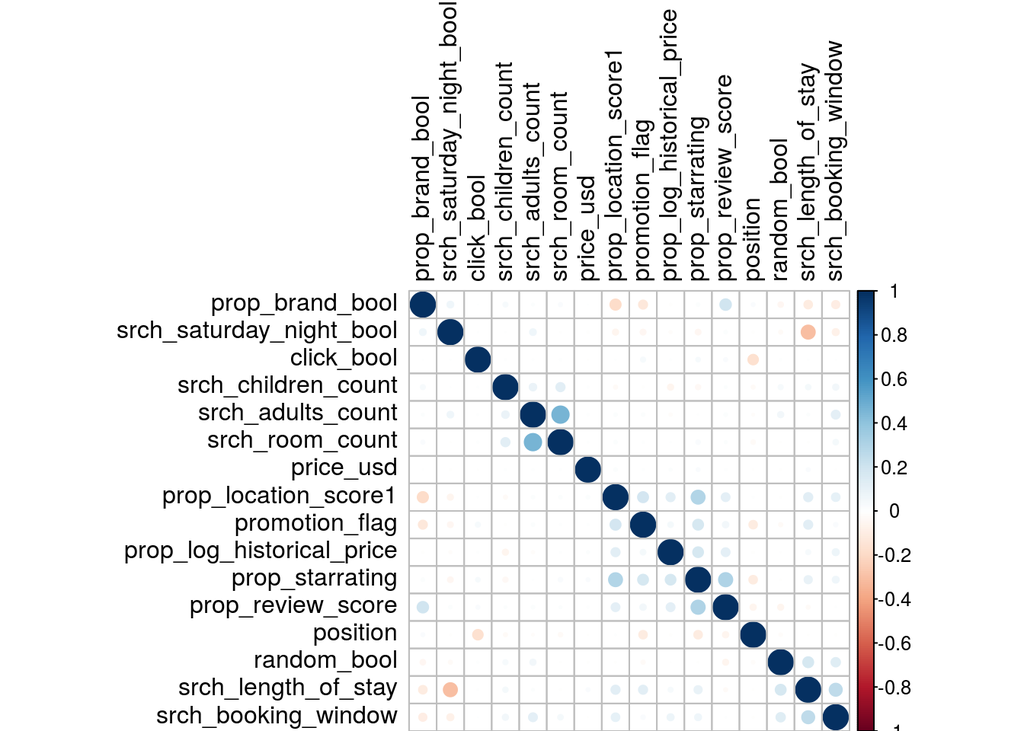

```r
a1 = cor(dataSelect[, which(sapply(dataSelect,class) %in% c("numeric","integer","logical"))])
corrplot(a1, method="circle", order = "hclust", tl.col = "black", tl.srt = 90)
```

## 4.4 檢視有沒有點擊下，各欄位分佈狀況

僅prop_brand_bool, promotion_flag與position較能看見兩者不同，可預期分類不會理想。至於price_usd可能有離群值問題，則於後續處理。

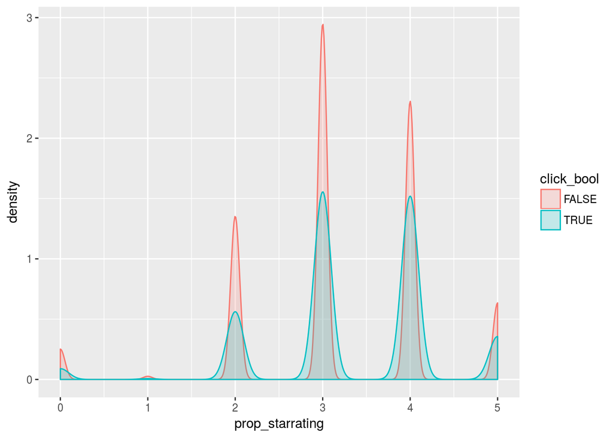

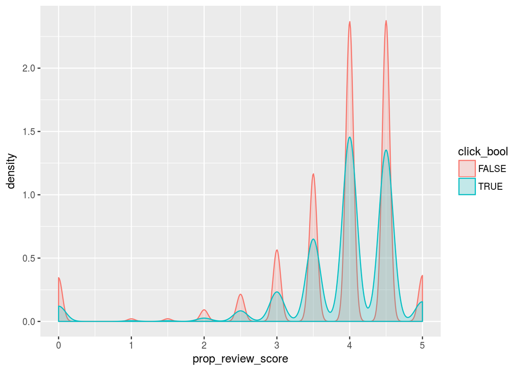

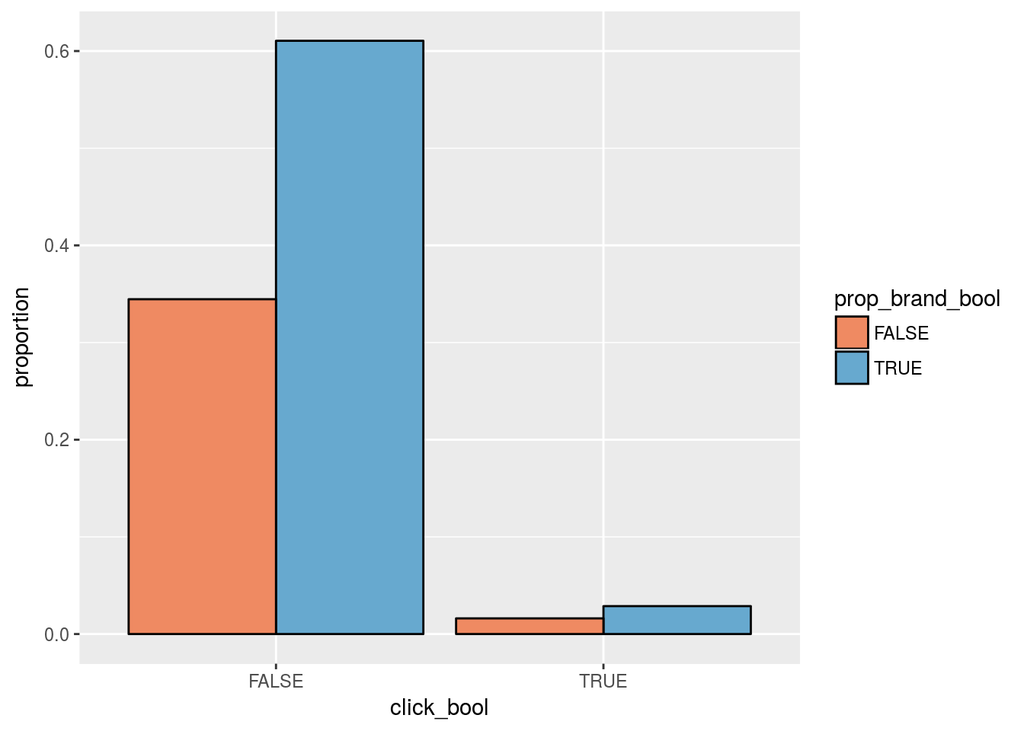

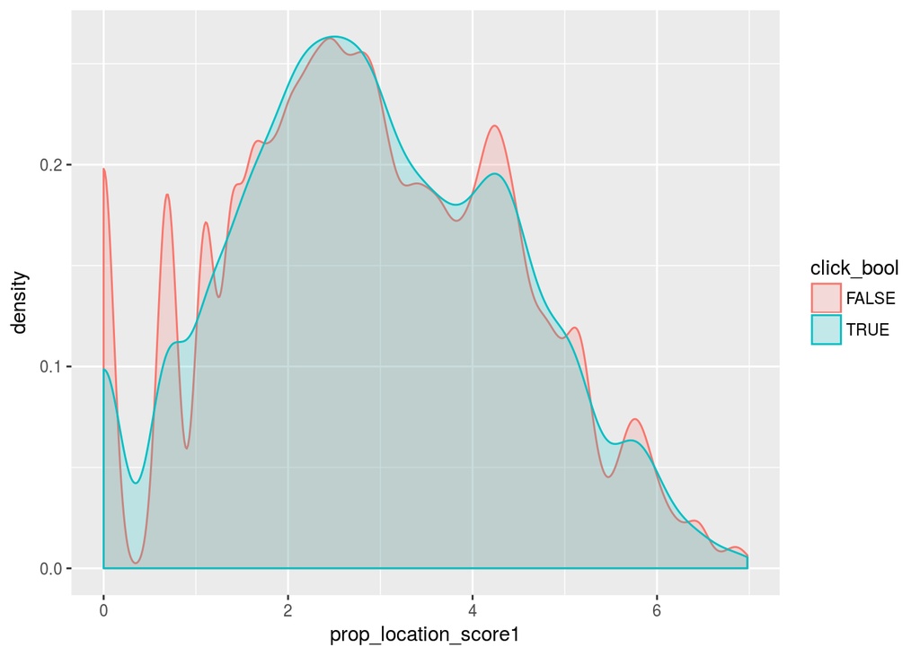

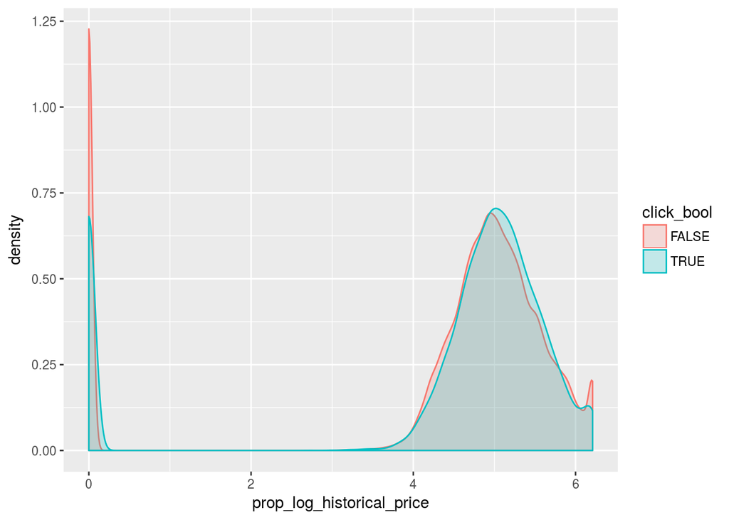

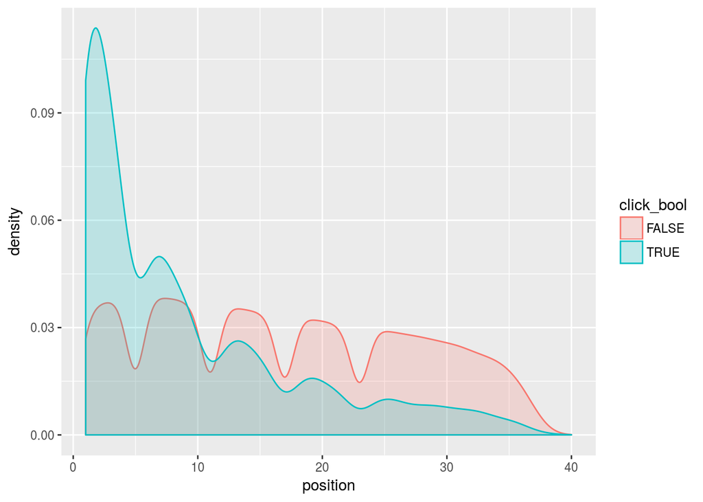

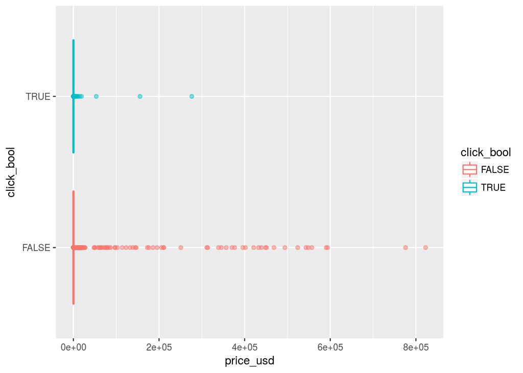

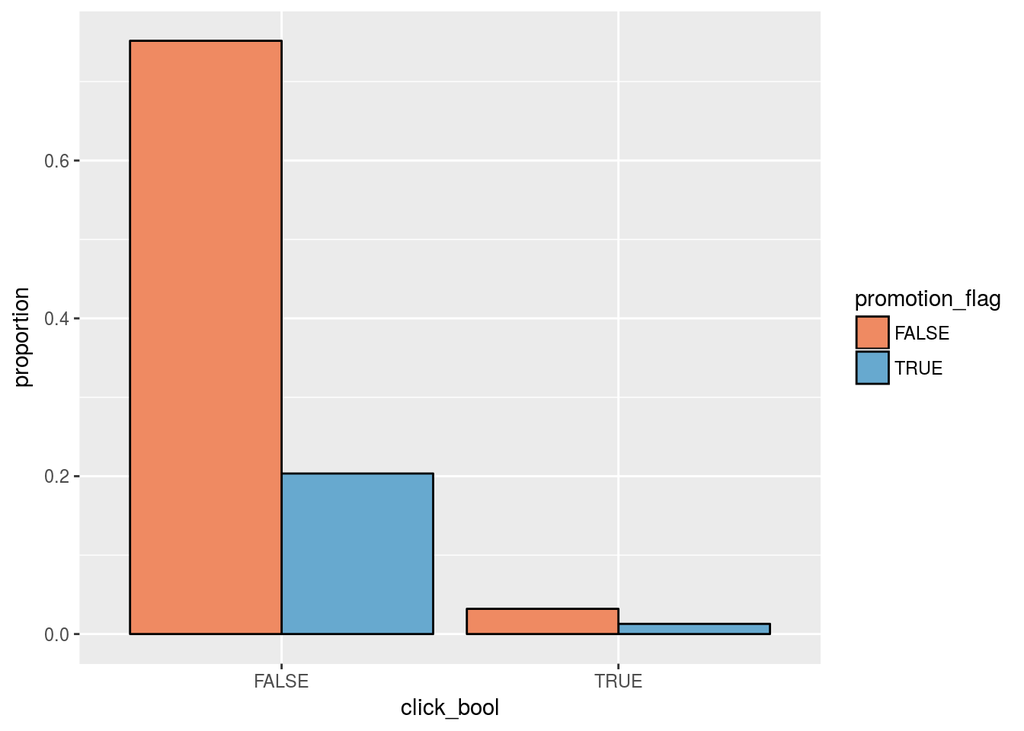

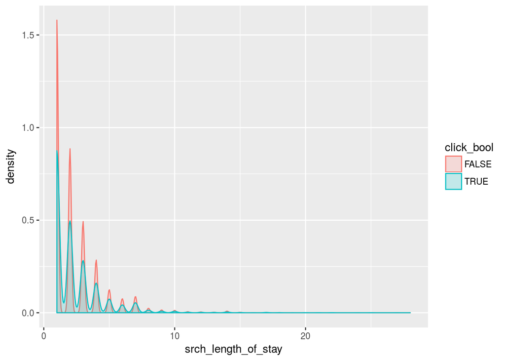

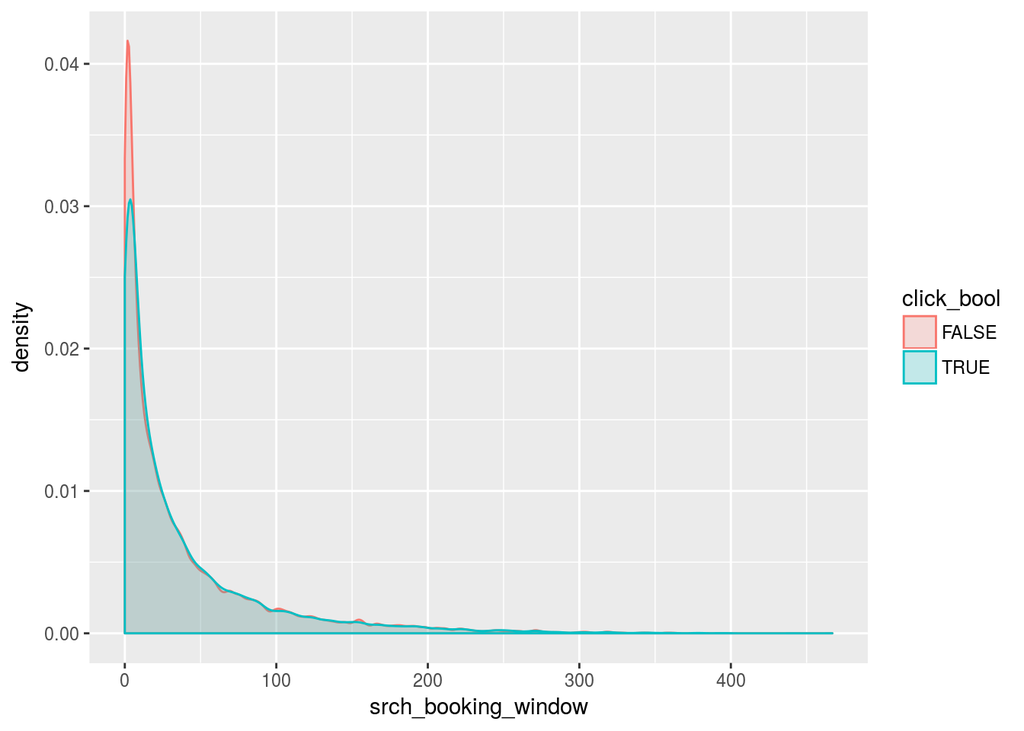

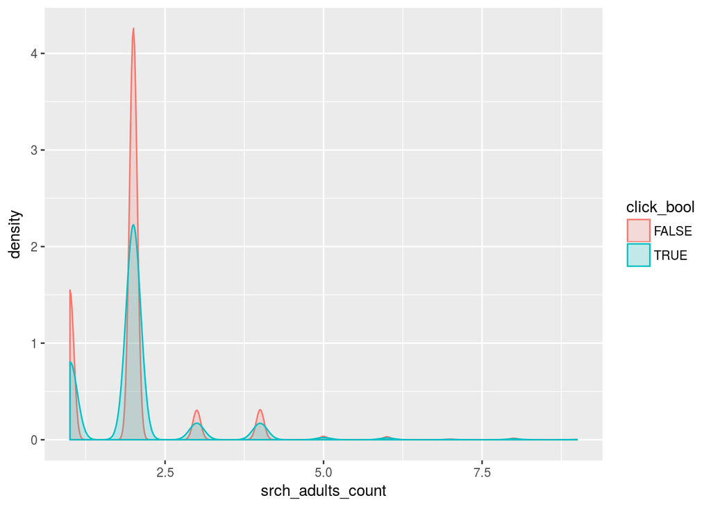

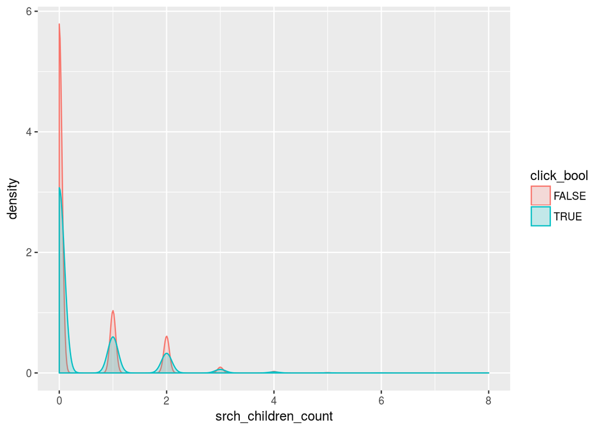

[3 more figures not shown]

```r
for (i in 1:(dim(dataSelect)[2]-1)){
        if (class(dataSelect[,i]) %in% c("numeric","integer")){
                if (colnames(dataSelect)[i]=='price_usd'){
                        plot1 = dataSelect %>%
                                ggplot(aes(x=click_bool, y=price_usd, colour=click_bool)) +
                                geom_boxplot(alpha = 0.5) +
                                coord_flip()
                        print(plot1)
                } else {
                        plot1 = dataSelect %>% ggplot(aes(x=dataSelect[,i], fill = click_bool, colour = click_bool)) + geom_density(alpha=0.2) +
                        xlab(colnames(dataSelect)[i])
                print(plot1)
                }

        } else if (class(dataSelect[,i]) == "logical") {
                plot1 = dataSelect %>% ggplot(aes(x = click_bool, y = (..count..)/sum(..count..),
                                          fill = dataSelect[,i])) +
                        geom_bar(position = "dodge", colour = "grey0") +
                        xlab('click_bool') + ylab('proportion') +
                        scale_fill_manual(values=c("#ef8a62","#67a9cf"),
                                          guide = guide_legend(title = colnames(dataSelect)[i]))
                print(plot1)
        }
}
```

# 5 資料切割

```r
dataClickTrue = dataSelect %>% filter(click_bool==TRUE)
dataClickFalse = dataSelect %>% filter(click_bool==FALSE)

dataClickTrueTrain = dataClickTrue[sample(dim(dataClickTrue)[1],dim(dataClickTrue)[1]*0.8),]
dataClickFalseTrain = dataClickFalse[sample(dim(dataClickFalse)[1],dim(dataClickFalse)[1]*0.8),]

dataClickTrueTest = setdiff(dataClickTrue, dataClickTrueTrain)
dataClickFalseTest = setdiff(dataClickFalse, dataClickFalseTrain)

dataTrain = rbind(dataClickTrueTrain, dataClickFalseTrain)
dataTest = rbind(dataClickTrueTest, dataClickFalseTest)
```

# 6 分類樹

採用10-fold cross validation，設定樹的長度為10。

結果是…….

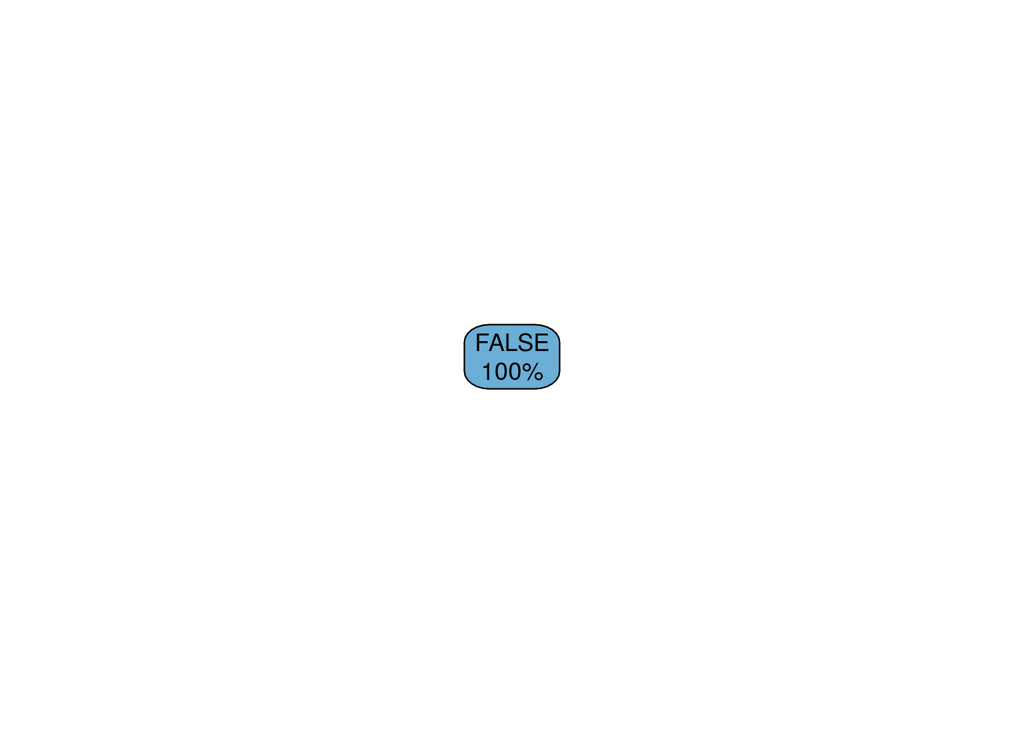

```r
tree_control = rpart.control(maxdepth = 10, xval = 10) #,
                             # minisplit=2, minbucket = 1)

tree_origin = rpart(formula = click_bool ~ .,
                      data = dataTrain,
                      method = "class",
                      control=tree_control)
rpart.plot(tree_origin, extra = 100)
```

## 6.1 Imbalanced Data

由於資料中類別極不平均，令資料各類出現次數接近可能分類較好，使用Under-Sampling及Over-Sampling嘗試處理。Under-Sampling指對類別次數多的資料抽樣，Over-Sampling指對類別次數少的資料重複抽樣，至出現次數接近類別較多的資料。

## 6.2 Under Sampling

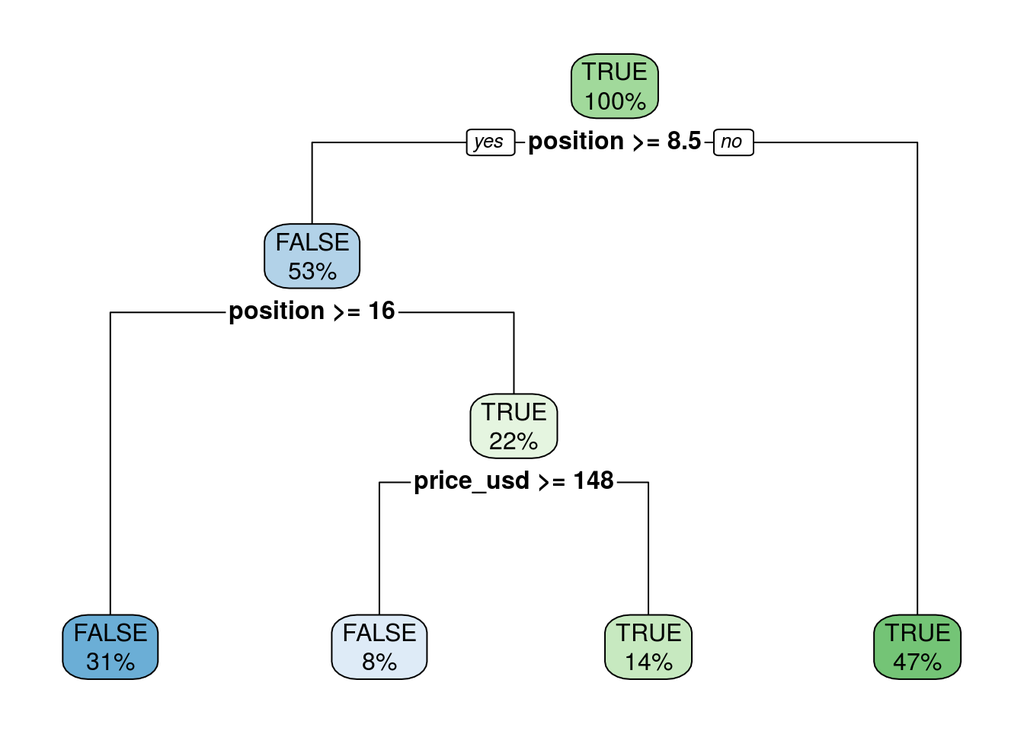

```r
set.seed(1234)
dataClickFalseTrainUnder =
        dataClickFalseTrain[
        sample(dim(dataClickFalse)[1],
               dim(dataClickTrueTrain)[1]
               ),
        ]

dataTrainUnderSample = rbind(dataClickFalseTrainUnder, dataClickTrueTrain)

tree_origin = rpart(formula = click_bool ~ .,
                      data = dataTrainUnderSample,
                      method = "class",
                      control=tree_control)
rpart.plot(tree_origin, extra = 100)
```

```r
printcp(tree_origin)
# resubstitution error rate          : rel error*Root node error = 0.52459*0.5 = 0.262295
# 10-fold cross-validated error rate : xerror*Root node error    = 0.80656*0.5 = 0.40328
# summary(tree_origin)
```

```
##
## Classification tree:
## rpart(formula = click_bool ~ ., data = dataTrainUnderSample,
##     method = "class", control = tree_control)
##
## Variables actually used in tree construction:
## [1] position  price_usd
##
## Root node error: 10034/22579 = 0.4444
##
## n=22579 (2511 observations deleted due to missingness)
##
##         CP nsplit rel error  xerror      xstd
## 1 0.265398      0   1.00000 1.00000 0.0074413
## 2 0.011013      1   0.73460 0.73969 0.0070346
## 3 0.010000      3   0.71258 0.72334 0.0069940
```

觀察nsplit與xerror那兩欄，nsplit指有多少個分支，xerror乘Root node error指對應的cross-validation error rate，可見分支越多，error rate有下降，這模型分支也不多，所以並無修剪，直接使用此模型。

```r
###剪樹
# # prune the tree
tree_prune = prune.rpart(tree_origin,cp=0)
# rpart.plot(tree_prune, extra = 100)
```

### 6.2.1 正確率–訓練

```r
# training
tree_pred = factor(predict(tree_prune, dataTrainUnderSample, type = "class"), levels = c('TRUE','FALSE'))
a1 = table(tree_pred, True_class = factor(dataTrainUnderSample$click_bool, levels = c('TRUE','FALSE')))
a2 = data.frame(item = c('precision','recall','accuracy','F-measure'),
                number = c(a1[1,1] / (a1[1,1]+a1[1,2]),
                           a1[1,1] / (a1[1,1]+a1[2,1]),
                           (a1[1,1]+a1[2,2]) / (sum(a1)),
                           (2)/( (1/(a1[1,1]/(a1[1,1]+a1[1,2]))) + (1/(a1[1,1]/(a1[1,1]+a1[2,1]))))
                )
)
print(a1)
```

```
##          True_class
## tree_pred TRUE FALSE
##     TRUE  9522  4127
##     FALSE 3023  5907
```

```r
print(a2)
```

```
##        item    number
## 1 precision 0.6976335
## 2    recall 0.7590275
## 3  accuracy 0.6833341
## 4 F-measure 0.7270367
```

### 6.2.2 正確率–測試

```r
# testing
tree_pred = factor(predict(tree_prune, dataTest, type = "class"), levels = c('TRUE','FALSE'))
a1 = table(tree_pred, True_class = factor(dataTest$click_bool, levels = c('TRUE','FALSE')))
a2 = data.frame(item = c('precision','recall','accuracy','F-measure'),
                number = c(a1[1,1] / (a1[1,1]+a1[1,2]),
                           a1[1,1] / (a1[1,1]+a1[2,1]),
                           (a1[1,1]+a1[2,2]) / (sum(a1)),
                           (2)/( (1/(a1[1,1]/(a1[1,1]+a1[1,2]))) + (1/(a1[1,1]/(a1[1,1]+a1[2,1]))))
                )
)
print(a1)
```

```
##          True_class
## tree_pred  TRUE FALSE
##     TRUE   2366 27467
##     FALSE   770 39291
```

```r
print(a2)
```

```
##        item     number
## 1 precision 0.07930815
## 2    recall 0.75446429
## 3  accuracy 0.59600252
## 4 F-measure 0.14352877
```

在訓練集的時候表現不算太好，至少不昰離譜，但到了測試，就錯得非常離譜，預測會點擊的，事實很多都沒點擊，只有recall能保持與訓練集接近。

## 6.3 Over Sampling

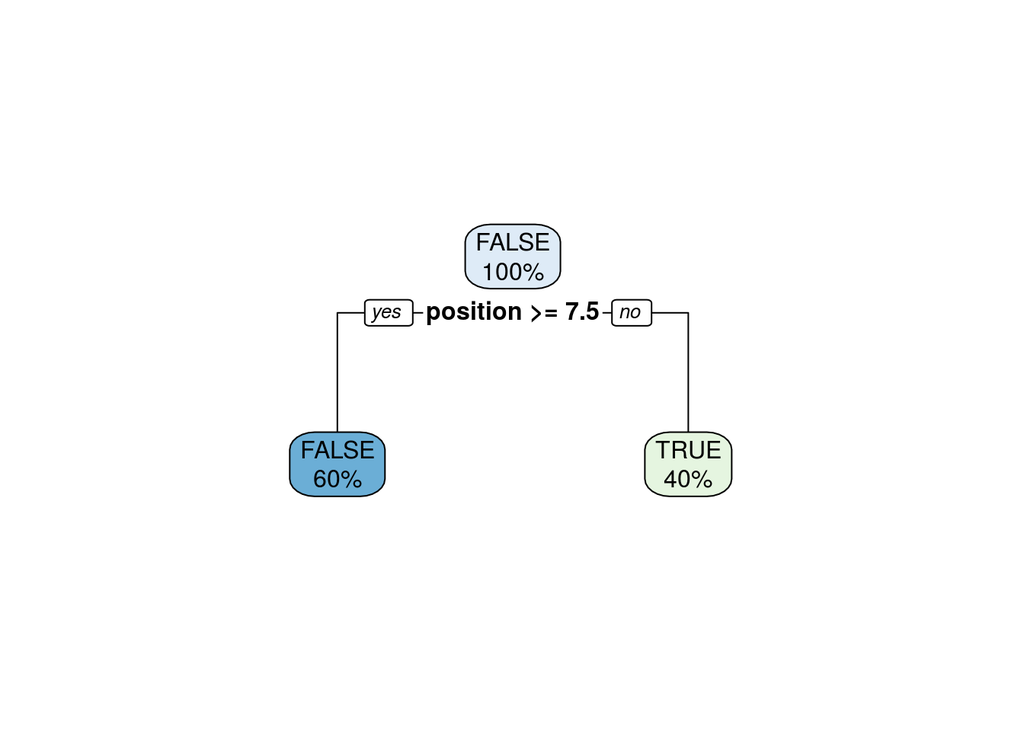

```r
set.seed(1234)
s1 = sample(dim(dataClickTrueTrain)[1], dim(dataClickFalseTrain)[1], replace = TRUE)
dataTrainOverSample = rbind(dataClickTrueTrain[s1,], as.data.frame(dataClickFalseTrain))

tree_origin = rpart(formula = click_bool ~ .,
                      data = dataTrainOverSample,
                      method = "class",
                      control=tree_control)
rpart.plot(tree_origin, extra = 100)
```

```r
printcp(tree_origin)
# resubstitution error rate          : rel error*Root node error = 0.52459*0.5 = 0.262295
# 10-fold cross-validated error rate : xerror*Root node error    = 0.80656*0.5 = 0.40328
# summary(tree_origin)
```

```
##
## Classification tree:
## rpart(formula = click_bool ~ ., data = dataTrainOverSample, method = "class",
##     control = tree_control)
##
## Variables actually used in tree construction:
## [1] position
##
## Root node error: 267056/534112 = 0.5
##
## n= 534112
##
##        CP nsplit rel error  xerror      xstd
## 1 0.36056      0   1.00000 1.00240 0.0013683
## 2 0.01000      1   0.63944 0.63944 0.0012763
```

```r
###剪樹
# # prune the tree
tree_prune = prune.rpart(tree_origin,cp=0)
# rpart.plot(tree_prune, extra = 100)
```

### 6.3.1 正確率–訓練

```r
# training
tree_pred = factor(predict(tree_prune, dataTrainOverSample, type = "class"),levels = c('TRUE','FALSE'))
a1 = table(tree_pred, True_class = factor(dataTrainOverSample$click_bool, levels = c('TRUE','FALSE')))
a2 = data.frame(item = c('precision','recall','accuracy','F-measure'),
                number = c(a1[1,1] / (a1[1,1]+a1[1,2]),
                           a1[1,1] / (a1[1,1]+a1[2,1]),
                           (a1[1,1]+a1[2,2]) / (sum(a1)),
                           (2)/( (1/(a1[1,1]/(a1[1,1]+a1[1,2]))) + (1/(a1[1,1]/(a1[1,1]+a1[2,1]))))
                )
)
print(a1)
```

```
##          True_class
## tree_pred   TRUE  FALSE
##     TRUE  156217  59926
##     FALSE 110839 207130
```

```r
print(a2)
```

```
##        item    number
## 1 precision 0.7227484
## 2    recall 0.5849597
## 3  accuracy 0.6802824
## 4 F-measure 0.6465949
```

### 6.3.2 正確率–測試

```r
# testing
tree_pred = factor(predict(tree_prune, dataTest, type = "class"), levels = c('TRUE','FALSE'))
a1 = table(tree_pred, True_class = factor(dataTest$click_bool, levels = c('TRUE','FALSE')))
a2 = data.frame(item = c('precision','recall','accuracy','F-measure'),
                number = c(a1[1,1] / (a1[1,1]+a1[1,2]),
                           a1[1,1] / (a1[1,1]+a1[2,1]),
                           (a1[1,1]+a1[2,2]) / (sum(a1)),
                           (2)/( (1/(a1[1,1]/(a1[1,1]+a1[1,2]))) + (1/(a1[1,1]/(a1[1,1]+a1[2,1]))))
                )
)
print(a1)
```

```
##          True_class
## tree_pred  TRUE FALSE
##     TRUE   1801 14953
##     FALSE  1335 51805
```

```r
print(a2)
```

```
##        item    number
## 1 precision 0.1074967
## 2    recall 0.5742985
## 3  accuracy 0.7669614
## 4 F-measure 0.1810960
```

從測試資料來看，precision、accuracy與F-measure比剛才Under-Sampling的好一點，但precision仍然太低。

可見分類結果非常差，之後會嘗試加入其他欄位、加權調整及其他演算法。